# Part 2 - Basic Data Wrangling and Functions/Classes

- IF Statement
- FOR statement
- WHILE statement
- FUNCTION
- CLASS

## Conditional statement

The following conditional statements that Python support

- Equality: ==
- Not Equal: !=
- greater than: >
- less than: <
- greater than or equal to: >=
- less than or equal to: <=
- in: in
- Not in: not in

The followings are conditional function

- if
- elif: else if
- else

### boolean class

It is a class of boolean (bool).  
It is derived from comparison.

### Difference from SAS

- No need for semicolon for statement
- need to include colon(:) for if, for and while statements
- '=' means assigning the values vs '==' means the comparision

```python
## Comparion
race = 'white'  ## assigning
print(race == 'white') ## comparison
print(race == 'black')

## assign comparison to boolean
ans = race=='white'
print(ans)
print(type(ans))
```

```
True
False
True
<class 'bool'>
```

Boolean value is either True or False

```python
## if and elif statement
age = 13

if age < 4:
    print("Admisison price is $0")
elif age < 12:
    print("Admission price is $10")
else:
    print("Admission price is $20")

if age >5 :
    print()
    print()
    print()
print()
```

```
Admission price is $20
```

```python
## Manual development of Boolean
bool_a = True
print(bool_a)
print(type(bool_a))
```

```
True
<class 'bool'>
```

```python
## comparison statements
age = 5
if age == 5:
    print("The age of " + str(age) + " is a correct age")

if age != 6:
    print("The age of " + str(age) + " is not a correct age")

if age >= 5:
    print("He is " + str(age) + " years old. He is greater than or equal to 5")

if age > 4:
    print("He is " + str(age) + " years old. He is greater than 4")
```

```
The age of 5 is a correct age
The age of 5 is not a correct age
He is 5 years old. He is greater than or equal to 5
He is 5 years old. He is greater than 4
```

```python
## use "in" comparision and list class
list_vital = ['weight','blood pressure','height']

if 'weight' in list_vital:
    print('weight')
if 'height' in list_vital:
    print('height')
if 'blood pressure' in list_vital:
    print('blood pressure')
```

```
weight
height
blood pressure
```

```python
### use tuple class
list_vital = ('weight','blood pressure','height')

if 'weight' in list_vital:
    print('weight')
if 'height' in list_vital:
    print('height')
if 'blood pressure' in list_vital:
    print('blood pressure')
```

```
weight
height
blood pressure
```

```python
### use tuple class
#list_vital = ('weight','blood pressure','height')

if 'weight' in ['weight','blood pressure','height']:
    print('weight')
```

```
weight
```

## For statement

"for" loop is used for iterating over sequence (list, tuple, set, dictionary, or string)

```python
## using FOR loops with list
CT_AESEV = ['mild', 'moderate', 'severe']
for ct in CT_AESEV:
    print(ct)
```

```
mild
moderate
severe
```

```python
## For loop for dictionary
subject3 = {'subjid': '001-002', 'sex':'female', 'race':'asian'}
for key, value in subject3.items():
    print("Key: " + key)
    print("Value: " + value)
```

```
Key: subjid
Value: 001-002
Key: sex
Value: female
Key: race
Value: asian
```

## While statement

"for" loop goes through a collection of items and executes codes for each items. "while" loop runs as long as a certain condition is met.

```python
## example of while statement
num = 5
while num != 0:
    print(num)
    num -= 1
```

```
5
4
3
2
1
```

### Combined for loop and if statement

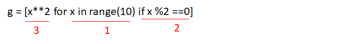

```python
g = [x**2 for x in range(10) if x %2 ==0]
g
```

```
[0, 4, 16, 36, 64]
```

```python
g2 = []
for x2 in range(10):
    if x2 % 2 == 0:
        g2.append(x2**2)
g2
```

```
[0, 4, 16, 36, 64]
```

## Functions

Functions in Python are the assigned blocks of codes that are designed to do a certain specific job.

Its structure is  
def name(arguments):  
codes

[output not shown]

name(arguments)

```python
## simple function
def print_hello():
    print("Hello")
```

```python
print_hello()
```

```
Hello
```

```python
## using arguments in function
def print_name(name):
    print("Hello, " + name)
```

```python
print_name('Kevin')
```

```
Hello, Kevin
```

```python
print_name(name='Mary')
```

```
Hello, Mary
```

```python
## Returning values
def ae_sev(ae_sev_code):
    ct_aesev_conv = {1:'mild', 2:'moderate', 3:'severe'}
    ae_sev = "Not Available"

    for key, value in ct_aesev_conv.items():
        if ae_sev_code == key:
            ae_sev = value
    return ae_sev
```

```python
## call ae_sev function
AESEV = ae_sev(1)
print(AESEV)

AESEV = ae_sev(5)
print(AESEV)
```

```
mild
Not Available
```

### import function from modules

Call other python program to import the function

[figure not shown]

```python
## importing entire module of utility.py in the same directory
import utility
utility.print_function("John")
```

```
You are  John .
```

```python
## using alias from module
import utility as ut
ut.print_function("Steve")
```

```
You are  Steve .
```

```python
## importing specific functions from module
from utility import print_function
print_function("Phil")
```

```
You are  Phil .
```

```python
## importing all functions from module
from utility import *
print_function("Mary")
```

```
You are  Mary .
```

## Lambda - anomouos function (a function without the name)

```python
## normal function
def sqrt(x):
    return x*x
print(sqrt(9))
print(type(sqrt))
```

```
81
<class 'function'>
```

```python
sqrt2 = lambda x: x*x
print(sqrt2(8))
type(sqrt2)
```

```
64
```

```
function
```

### difference between function and lambda

- function need function name and need to pass value and need return statement
- lambda can be anywhere. It is simple.

### The main ways lambda expressions are different from def:

- They can be immediately passed around (no variable needed)
- They can only have a single line of code within them
- They return automatically
- They can’t have a docstring and they don’t have a name
- They use a different and unfamiliar syntax

```python
a = [(4, 2), (2, 1), (9, 10), (13, -3)]
print("Original List a         : ", a)

## After sorting list method
a.sort()
print("List a after sort method: ",a)
print(type(a))

## pick up the second value in each tuple
def sortSecond(val):
    return val[1]

## sort using function
## list.sort(reverse=True|False, key=myFunc)
a.sort(key= sortSecond) # sortSecond function dictate sort method to sort the second item of each tuplip
print("\nList a after sortSecond function: ",a)
```

```
Original List a         :  [(4, 2), (2, 1), (9, 10), (13, -3)]
List a after sort method:  [(2, 1), (4, 2), (9, 10), (13, -3)]
<class 'list'>

List a after sortSecond function:  [(13, -3), (2, 1), (4, 2), (9, 10)]
```

```python
## sort using lambda
a.sort()
print("List a after sort method: ", a)
a.sort(key = lambda x: x[1])  ## This lamda function ask to sort the second iteam of tulip
print("\nnew sorted a using lambda: ",a)
```

```
List a after sort method:  [(2, 1), (4, 2), (9, 10), (13, -3)]

new sorted a using lambda:  [(13, -3), (2, 1), (4, 2), (9, 10)]
```

## Classes

Classes are objects that bind data and functionality together.  
Class objects support attribute references and instaniation.

- attribute: the attribute of class
- instance: create new objects from Class

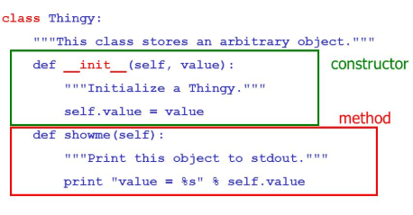

```python
## Create class object with attribute and method
class my_class2():
    def __init__(self, name, course):  ## Attribute- "self" will enable all the attributes can be used in all other functions(method)
        self.name = name
        self.course = course

    def print_report(self): ## method( a function that's part of a class). "self" can call all the attributes
        print("Your name is ", self.name)
        print("You will take ", self.course)
```

```python
## Use class and object (an instance of object)
## Class - my_class2
## object - my_intance
my_instance = my_class2('John', 'Computer') # object - instance of Class
print("The attribute of instance: ", my_instance.name)
print("\nCall the method: ")
my_instance.print_report()
```

```
The attribute of instance:  John

Call the method:
Your name is  John
You will take  Computer
```

```python
### the information of my object
print(type(my_instance))
print("list of attributes : ", vars(my_instance)) ## list of attributes
print("list of attributes and methods : ", dir(my_instance))

print("list of attributes and methods : ", my_instance.__dict__)
```

```
<class '__main__.my_class2'>
list of attributes :  {'name': 'John', 'course': 'Computer'}
list of attributes and methods :  ['__class__', '__delattr__', '__dict__', '__dir__', '__doc__', '__eq__', '__format__', '__ge__', '__getattribute__', '__gt__', '__hash__', '__init__', '__init_subclass__', '__le__', '__lt__', '__module__', '__ne__', '__new__', '__reduce__', '__reduce_ex__', '__repr_…
list of attributes and methods :  {'name': 'John', 'course': 'Computer'}
```

```python
### the information of the object
print(type(my_instance))
print("list of attributes : ", vars(my_instance)) ## list of attributes and its values
print("list of attributes and methods : ", dir(my_instance))
```

```
<class '__main__.my_class2'>
list of attributes :  {'name': 'John', 'course': 'Computer'}
list of attributes and methods :  ['__class__', '__delattr__', '__dict__', '__dir__', '__doc__', '__eq__', '__format__', '__ge__', '__getattribute__', '__gt__', '__hash__', '__init__', '__init_subclass__', '__le__', '__lt__', '__module__', '__ne__', '__new__', '__reduce__', '__reduce_ex__', '__repr_…
```

```python
## Previous object List a
a = [(4, 2), (2, 1), (9, 10), (13, -3)]
print(type(a))
print(dir(a))
```

```
<class 'list'>
['__add__', '__class__', '__contains__', '__delattr__', '__delitem__', '__dir__', '__doc__', '__eq__', '__format__', '__ge__', '__getattribute__', '__getitem__', '__gt__', '__hash__', '__iadd__', '__imul__', '__init__', '__init_subclass__', '__iter__', '__le__', '__len__', '__lt__', '__mul__', '__ne…
```